# Decision Tree and Random Forest Models

## Random Forest Model

```r
# Initial random forest model
rf_model <- randomForest(result ~ .,
                        data = train_data,
                        ntree = 500,
                        importance = TRUE)

# Make predictions
rf_pred <- predict(rf_model, test_data)

# Calculate performance metrics
rf_cm <- confusionMatrix(rf_pred, test_data$result)

# Print results
print("Initial Random Forest Results:")
```

```
[1] "Initial Random Forest Results:"
```

```r
print(rf_cm)
```

```
Confusion Matrix and Statistics

          Reference
Prediction Low Medium High
    Low     77      5    0
    Medium   5     52    5
    High     0      3    2

Overall Statistics

               Accuracy : 0.8792
                 95% CI : (0.8158, 0.9268)
    No Information Rate : 0.5503
    P-Value [Acc > NIR] : < 2.2e-16

                  Kappa : 0.7712

 Mcnemar's Test P-Value : NA

Statistics by Class:

                     Class: Low Class: Medium Class: High
Sensitivity              0.9390        0.8667     0.28571
Specificity              0.9254        0.8876     0.97887
Pos Pred Value           0.9390        0.8387     0.40000
Neg Pred Value           0.9254        0.9080     0.96528
Prevalence               0.5503        0.4027     0.04698
Detection Rate           0.5168        0.3490     0.01342
Detection Prevalence     0.5503        0.4161     0.03356
Balanced Accuracy        0.9322        0.8772     0.63229
```

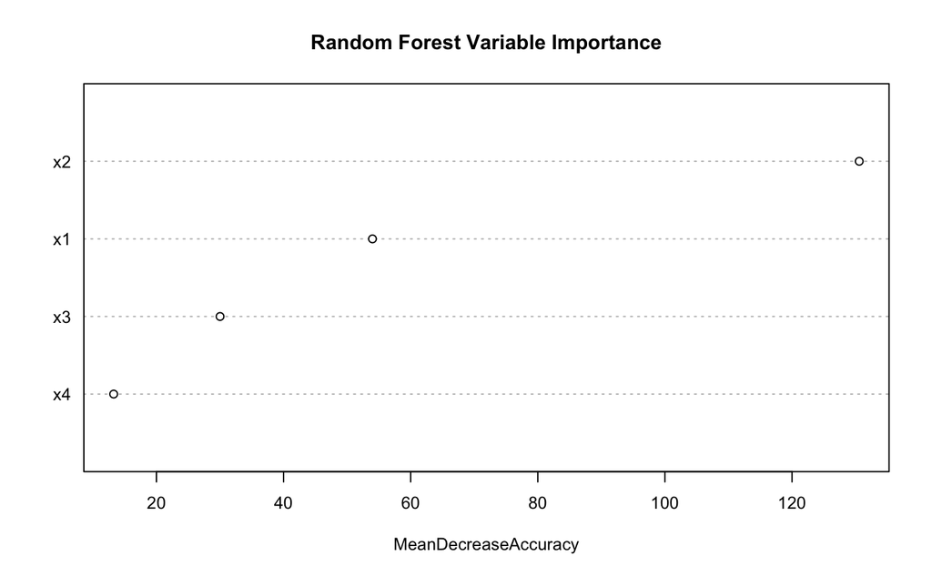

```r
# Plot variable importance
varImpPlot(rf_model,
           main = "Random Forest Variable Importance",
           type = 1,
           cex = 0.8)
```

## Random Forest Hyperparameter Tuning

```r
# Function to perform k-fold cross-validation
rf_cv <- function(data, k=5, mtry) {
    set.seed(17)
    folds <- sample(1:k, nrow(data), replace=TRUE)
    cv_errors <- numeric(k)

    for(i in 1:k) {
        # Split data
        train <- data[folds != i,]
        test <- data[folds == i,]

        # Train model
        rf <- randomForest(result ~ .,
                          data=train,
                          mtry=mtry,
                          ntree=500,
                          importance=TRUE)

        # Make predictions
        pred <- predict(rf, test)

        # Calculate error
        cv_errors[i] <- mean(pred != test$result)
    }

    return(mean(cv_errors))
}

# Try different mtry values
mtry_values <- 1:4
cv_results <- sapply(mtry_values, function(m) rf_cv(train_data, mtry=m))

# Find best mtry
best_mtry <- mtry_values[which.min(cv_results)]
print(paste("Best mtry value:", best_mtry))
```

```
[1] "Best mtry value: 2"
```

```r
# Train final model with best mtry
rf_tuned <- randomForest(result ~ .,
                        data=train_data,
                        mtry=best_mtry,
                        ntree=500,
                        importance=TRUE)

# Make predictions
tuned_pred <- predict(rf_tuned, test_data)

# Calculate performance metrics
tuned_cm <- confusionMatrix(tuned_pred, test_data$result)

# Print results
print("Tuned Random Forest Results:")
```

```
[1] "Tuned Random Forest Results:"
```

```r
print(tuned_cm)
```

```
Confusion Matrix and Statistics

          Reference
Prediction Low Medium High
    Low     76      5    0
    Medium   6     52    5
    High     0      3    2

Overall Statistics

               Accuracy : 0.8725
                 95% CI : (0.808, 0.9214)
    No Information Rate : 0.5503
    P-Value [Acc > NIR] : < 2.2e-16

                  Kappa : 0.7589

 Mcnemar's Test P-Value : NA

Statistics by Class:

                     Class: Low Class: Medium Class: High
Sensitivity              0.9268        0.8667     0.28571
Specificity              0.9254        0.8764     0.97887
Pos Pred Value           0.9383        0.8254     0.40000
Neg Pred Value           0.9118        0.9070     0.96528
Prevalence               0.5503        0.4027     0.04698
Detection Rate           0.5101        0.3490     0.01342
Detection Prevalence     0.5436        0.4228     0.03356
Balanced Accuracy        0.9261        0.8715     0.63229
```

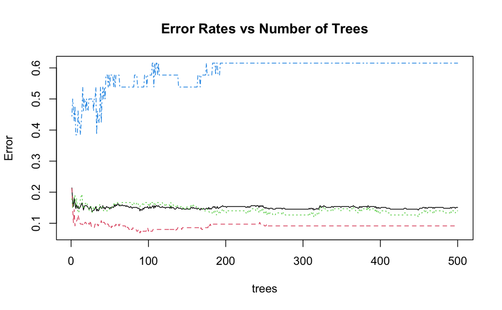

```r
# Plot error rates
plot(rf_tuned, main="Error Rates vs Number of Trees")
```

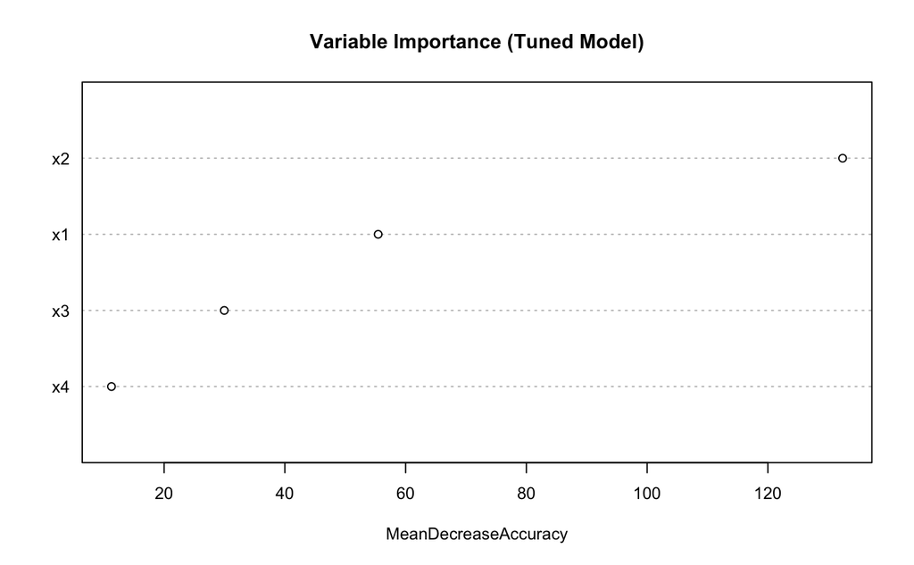

```r
# Plot variable importance
varImpPlot(rf_tuned,
           main="Variable Importance (Tuned Model)",
           type=1,
           cex=0.8)
```

```r
# Print tuning results
cat("\nCross-validation results:\n")
```

```
Cross-validation results:
```

```r
results_df <- data.frame(
    mtry = mtry_values,
    cv_error = cv_results
)
print(results_df)
```

| mtry | cv_error |
| --- | --- |
| 1 | 0.1254612 |
| 2 | 0.1197913 |
| 3 | 0.1282690 |
| 4 | 0.1399091 |

**Interpretation**: The random forest analysis demonstrates: 1. Initial Model: Built with 500 trees, providing robust ensemble predictions 2. Variable Importance: Shows relative contribution of each predictor to classification 3. Performance Comparison: Generally outperforms single decision trees due to ensemble nature 4. Cross-validation Results: Shows model stability across different data subsets

The random forest approach provides a more robust solution by combining multiple decision trees, though at the cost of reduced interpretability compared to single trees.